# 15: Analysis of quantitative data

Author

Thiago Cerqueira Silva

This computer practical uses the whitehal.dta data set, a subset of data from the Whitehall cohort study. It contains data on risk factors for ischaemic heart disease collected in male civil servants between 1967-69. The variables we are interested in were all collected at entry to the study and so the data can be thought of as cross-sectional. Systolic blood pressure (sbp) is the quantitative outcome, and the aim of the practical is to quantify the relationship between sbp and occupational grade (grade4).

These are the variables of interest: * *Outcome*: systolic blood pressure (continuous: `sbp`) * *Exposure*: job grade (categorical: `grade4`) * *Confounder*: age (continuous: `agein`)

Note that in the data grade4 is coded 1=admin; 2=professional/executive; 3=clerical; 4=other

```r
library(haven)
# create table
library(gtsummary)
# data wrangling and other functions
library(tidyverse)
# if you want to have a output similar to stata
library(tidylog)
#cox
library(survival)

# Limit significant digits to 3, remove scientific notation (most of the time, scipen=999 removes all time)
options(digits = 3, scipen = 9)
```

# Q1

Find the mean (systolic) blood pressure by categories of grade4

```r
white <- read_dta("datasets/WHITEHAL.DTA") |>
  mutate(across(where(is.labelled),as_factor))
```

```r
white |>
  mutate(grade4 = as.factor(grade4)) |>
  group_by(grade4) |>
  summarise(mean_sbp = mean(sbp),
            sd_sbp = sd(sbp),
            median_sbp = median(sbp),
            iqr_sbp = IQR(sbp))
```

| grade4 | mean_sbp | sd_sbp | median_sbp | iqr_sbp |
| --- | --- | --- | --- | --- |
| 1 | 133 | 19.1 | 132 | 22.0 |
| 2 | 135 | 19.5 | 133 | 27.0 |
| 3 | 139 | 23.9 | 136 | 31.0 |
| 4 | 139 | 24.8 | 137 | 34.5 |

# Q2

Estimate the regression model for sbp with grade categories as explanatory variables. What is the expected sbp with 95% confidence intervals:

1. for a man in grade 1?
2. for a man in grade 4?

Compare these estimates to your results for question 1.

```r
white <- white |>
  mutate(grade4 = as.factor(grade4))

lm_model <- lm(sbp ~ grade4, data=white)

marginaleffects::avg_predictions(lm_model, variables = "grade4") |> as_tibble()
```

| grade4 | estimate | std.error | statistic | p.value | s.value | conf.low | conf.high |
| --- | --- | --- | --- | --- | --- | --- | --- |
| 1 | 133 | 2.271 | 58.7 | 0 | Inf | 129 | 138 |
| 2 | 135 | 0.629 | 214.2 | 0 | Inf | 133 | 136 |
| 3 | 139 | 1.193 | 116.7 | 0 | Inf | 137 | 142 |
| 4 | 139 | 1.583 | 87.5 | 0 | Inf | 135 | 142 |

```r
# you can also get direct results fitting a model without intercept
#lm_no_intercept <- lm(sbp ~ -1 + grade4, data=white)
#broom::tidy(lm_no_intercept, conf.int=T)
```

**Coding explanation**

The code `marginaleffects::avg_predictions` generates the prediction of the model by each level of the variable defined in “variables”. Also, if you fit a model without intercept, it will provide the same answers (in this case without other variables)

# Q3

Using the output of the model you fitted in question 2, do you have evidence to suggest that systolic blood pressure is associated with occupational grade?

```r
empty_model <-lm(sbp ~ 1, data = white)
anova(empty_model, lm_model)
```

| Res.Df | RSS | Df | Sum of Sq | F | Pr(>F) |
| --- | --- | --- | --- | --- | --- |
| 1676 | 740195 | NA | NA | NA | NA |
| 1673 | 733272 | 3 | 6923 | 5.26 | 0.001 |

**Answer**

The anova (F test) indicates that compared to the null model, the new model with 3 more parameters (Df=3) has significantly improved the fit (F=5.27 and p=0.0013)

# Q4

Study the association between age at entry (agein) and sbp. Some of the tools you may wish to use are scatter plots, summaries of sbp by categories of agein, and regression models treating agein as linear, quadratic or categorical.

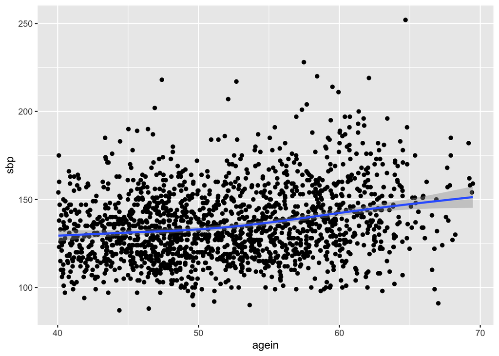

```r
white |>
  ggplot(aes(agein, sbp))+
  geom_point()+
  geom_smooth() # add a LOESS - Locally estimated scatterplot smoothing - curve
```

```r
# recode age

white <- white |>
  mutate(
    agegroup = case_when(
      agein>40 & agein<=45 ~ "41-45",
      agein<=50 ~ "46-50",
      agein <= 55 ~ "51-55",
      agein <= 60 ~ "56-60",
      agein <= 70 ~ "61-70"
    )
  )

white |>
  group_by(agegroup) |>
    summarise(mean_sbp = mean(sbp),
            sd_sbp = sd(sbp),
            median_sbp = median(sbp),
            iqr_sbp = IQR(sbp))
```

| agegroup | mean_sbp | sd_sbp | median_sbp | iqr_sbp |
| --- | --- | --- | --- | --- |
| 41-45 | 130 | 17.2 | 129 | 22.0 |
| 46-50 | 132 | 19.4 | 130 | 26.0 |
| 51-55 | 135 | 19.0 | 132 | 25.8 |
| 56-60 | 139 | 22.2 | 137 | 29.0 |
| 61-70 | 146 | 24.3 | 144 | 31.2 |

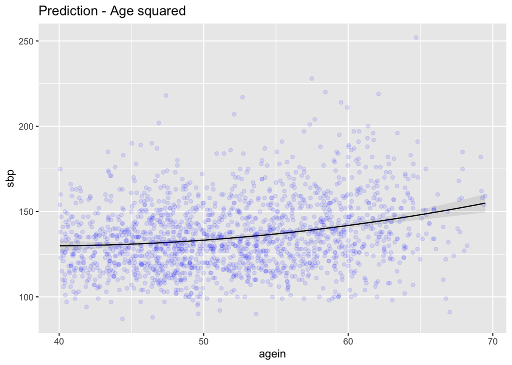

```r
# Models
#Linear
lm_lin <- lm(sbp ~ agein, data = white)
#marginaleffects::plot_predictions(lm_lin, condition = "agein")
# Quadratic
lm_qd <- lm(sbp ~ agein + I(agein*agein), data = white)

marginaleffects::plot_predictions(lm_qd, condition = "agein")+
  geom_point(data = white,aes(agein,sbp), alpha=0.1, color="blue")+
  labs(title="Prediction - Age squared")
```

```r
# compare models
anova(lm_lin, lm_qd)
```

| Res.Df | RSS | Df | Sum of Sq | F | Pr(>F) |
| --- | --- | --- | --- | --- | --- |
| 1675 | 697619 | NA | NA | NA | NA |
| 1674 | 694908 | 1 | 2711 | 6.53 | 0.011 |

**Answer**

The F-test indicate that including the quadratic term improves the fit.

# Q5

Before looking at the data, do you think that age may confound the relationship between grade4 and sbp? Now fit a linear regression model to find out if age is a confounder or not. Is there evidence to suggest that occupational grade is independently associated with systolic blood pressure (i.e. after adjustment for age)? Write a brief conclusion of your findings about the association between occupational grade and systolic blood pressure.

```r
lm_model_f <- lm(sbp ~ grade4 + agein +I(agein*agein), data=white)
broom::tidy(lm_model_f, conf.int=T)
```

| term | estimate | std.error | statistic | p.value | conf.low | conf.high |
| --- | --- | --- | --- | --- | --- | --- |
| (Intercept) | 167.975 | 28.80 | 5.832 | 0.000 | 111.485 | 224.466 |
| grade42 | 0.374 | 2.30 | 0.163 | 0.871 | -4.135 | 4.883 |
| grade43 | 1.482 | 2.54 | 0.583 | 0.560 | -3.502 | 6.466 |
| grade44 | -0.211 | 2.76 | -0.076 | 0.939 | -5.617 | 5.195 |
| agein | -2.000 | 1.10 | -1.813 | 0.070 | -4.164 | 0.164 |
| I(agein * agein) | 0.026 | 0.01 | 2.479 | 0.013 | 0.005 | 0.046 |

```r
anova(lm_model_f,
      lm(sbp ~ agein + I(agein*agein), white))
```

| Res.Df | RSS | Df | Sum of Sq | F | Pr(>F) |
| --- | --- | --- | --- | --- | --- |
| 1671 | 694491 | NA | NA | NA | NA |
| 1674 | 694908 | -3 | -417 | 0.335 | 0.8 |

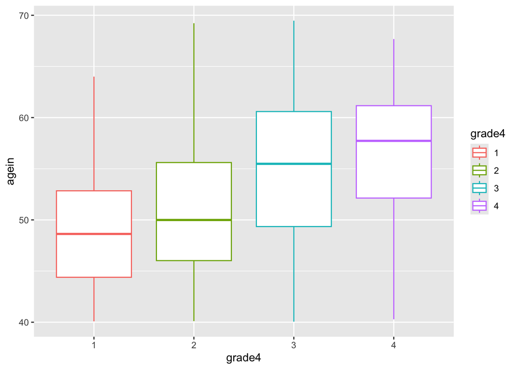

```r
white |>
  ggplot(aes(grade4,agein, color=grade4))+
  geom_boxplot()
```

**Answer**

Our conclusion is that systolic blood pressure appears to be associated with occupational grade but that this is only as a result of lower grade workers (coded 3, 4) being, on average, older. The real association is between age and systolic blood pressure.

# Q6

Obtain standardised residuals of your model and use these to check that the model assumptions are reasonable.

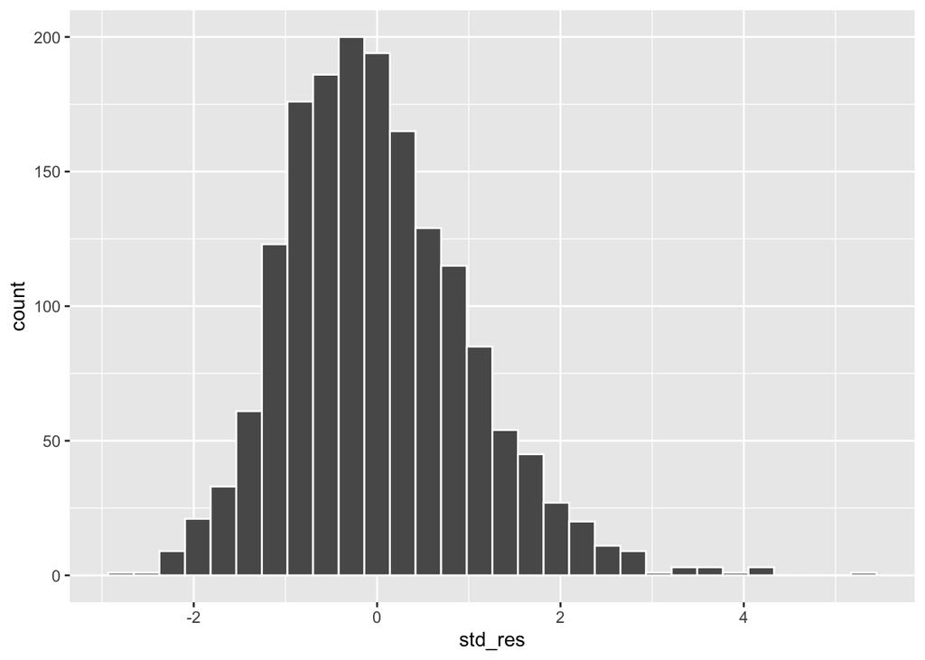

```r
white <- white |>
  mutate(std_res = rstandard(lm_model_f))

white |>
  ggplot(aes(std_res))+
  geom_histogram(color="white")
```

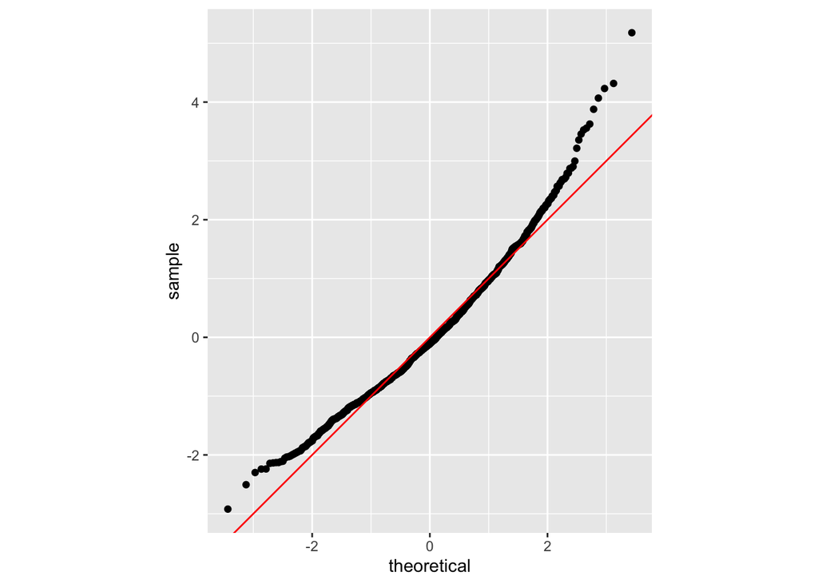

```r
white |>
  ggplot()+
 geom_qq(aes(sample=std_res)) +
  geom_abline(color = "red") +
  coord_fixed()
```

```r
# you can get a overall of diagnostics plots using performance::check_model
#performance::check_model(lm_model_f) # try yourself
```

**Answer**

A histogram of the residuals and the Normal quantile plot both show some positive skew, but not too bad considering the size of the sample. It isn’t necessary to plot both a histogram and a Normal quantile plot but both are shown here for demonstration.

# Q7

You probably found that the model residuals that you obtained in question 6 looked a bit skewed. A log-transformation of the outcome variable often removes skew.

1. Generate a new variable of log-transformed sbp
2. Estimate the regression model for lsbp with grade categories as explanatory variables, equivalent to the model you fitted in question 2.

```r
white <- white |>
  mutate(log_sbp = log(sbp))
lm_model_log <- lm(log_sbp ~ grade4, data=white)
broom::tidy(lm_model_log, conf.int=T)
```

| term | estimate | std.error | statistic | p.value | conf.low | conf.high |
| --- | --- | --- | --- | --- | --- | --- |
| (Intercept) | 4.882 | 0.016 | 299.814 | 0.000 | 4.850 | 4.914 |
| grade42 | 0.010 | 0.017 | 0.601 | 0.548 | -0.023 | 0.043 |
| grade43 | 0.040 | 0.018 | 2.156 | 0.031 | 0.004 | 0.076 |
| grade44 | 0.034 | 0.020 | 1.703 | 0.089 | -0.005 | 0.073 |

3. Obtain standardised residuals of this model and use these to check that the model assumptions are reasonable. Are the assumptions more appropriate now that you have log-transformed sbp?

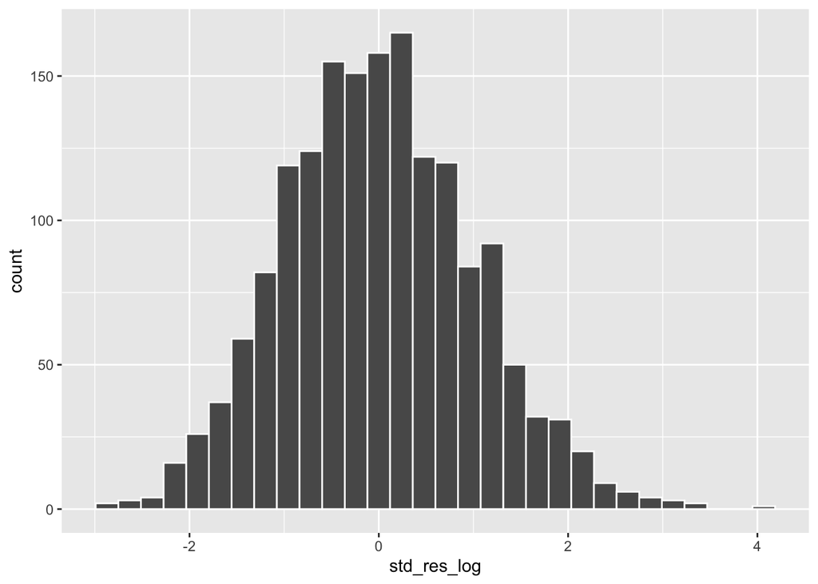

```r
white <- white |>
  mutate(std_res_log = rstandard(lm_model_log))

white |>
  ggplot(aes(std_res_log))+
  geom_histogram(color="white")
```

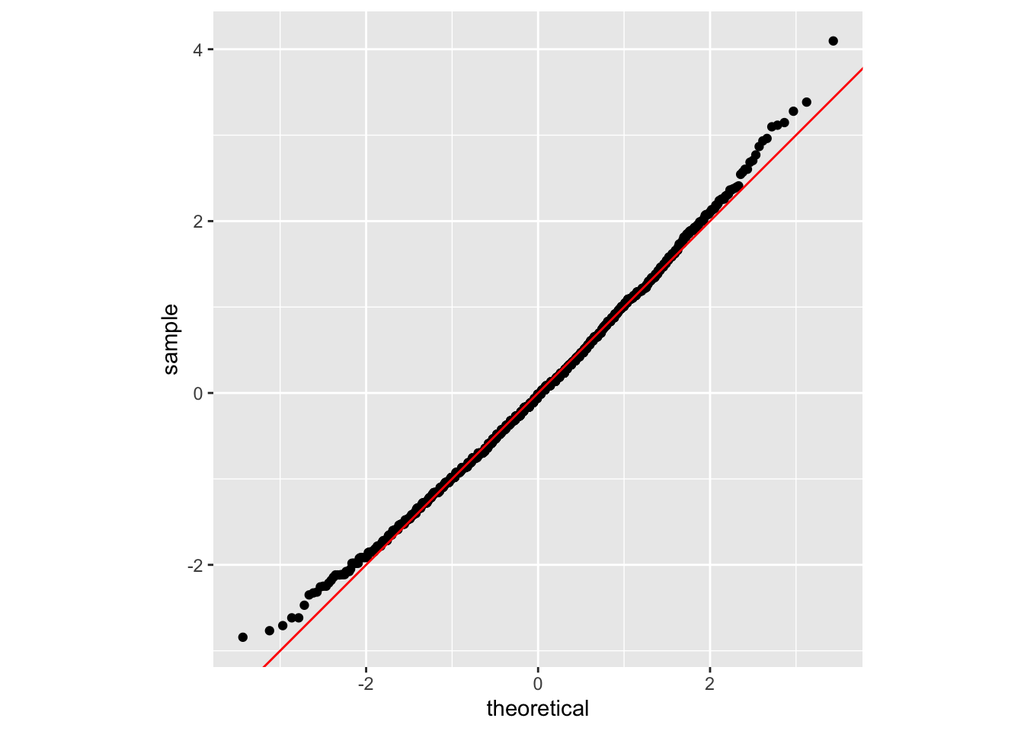

```r
white |>
  ggplot()+
 geom_qq(aes(sample=std_res_log)) +
  geom_abline(color = "red") +
  coord_fixed()
```

**Answer**

4. The parameter estimates from a linear regression model with a log-transformed outcome can be back-transformed by taking the exponential of the estimate. Compute the back-transformed estimate for occupational grade 4 compared to occupational grade 1

```r
broom::tidy(lm_model_log, conf.int=T, exponentiate=T)
```

| term | estimate | std.error | statistic | p.value | conf.low | conf.high |
| --- | --- | --- | --- | --- | --- | --- |
| (Intercept) | 131.94 | 0.016 | 299.814 | 0.000 | 127.791 | 136.22 |
| grade42 | 1.01 | 0.017 | 0.601 | 0.548 | 0.977 | 1.04 |
| grade43 | 1.04 | 0.018 | 2.156 | 0.031 | 1.004 | 1.08 |
| grade44 | 1.03 | 0.020 | 1.703 | 0.089 | 0.995 | 1.07 |

**Answer**

The back-transformed estimate for grade 4 compared to grade 1 is 1.034. This means that sbp is expected to be 3.4% higher (or 1.034 times higher) in workers in grade 4 compared to workers in grade 1

$$log(sbp) = a + \beta_2*grade_2+\beta_3*grade_3+\beta_4*grade_4
\newline
\text{for }grade_{4}\text{ the other betas will be 0, so}
log(sbp) = a + \beta_4*grade_4
\newline
log(sbp) - a = \beta_4*grade_4
\newline
a = log(sbp|grade_1)
\newline
log(sbp) - log(sbp|grade_1) = \beta_4*grade_4
\newline
grade_4=1
\newline
log(sbp) - log(sbp|grade_1) = \beta_4
\newline
log((sbp|grade_4)/(sbp|grade_1)) = \beta_4
\newline
(sbp|grade_4)/(sbp|grade_1) = exp(\beta_4)$$